# Breast Cancer

Claudio Palmeri, Pietro Sittoni  
23/09/2022

### Introduction

This dataset was created by Dr. William H. Wolberg.  
Each records represent a sample of breast tumor masses sampled using Fine Needle Aspiration (FNA).

### Sample of FNA

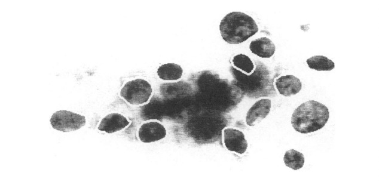

### The dataset

The dataset is composed by 32 columns and 569 row where each column represents:

- Id of the patient
- Status of the patient
- Ten real-valued features of the tumor cells computed from the analysis of a gray-scaled image:
  - radius
  - texture
  - perimeter
  - area
  - smoothness
  - compactness
  - concavity
  - concave points
  - symmetry
  - fractal dimension

Produced 3 quantities: mean, standard error, worst cases.

### Exploration of the dataset

Id

The first columns is called id and it represent the id number of the patient which is unique by design.

Diagnosis

```
  Diagnosis Number.of.cases
1 Malignant             212
2    Benign             357
```

### Radius

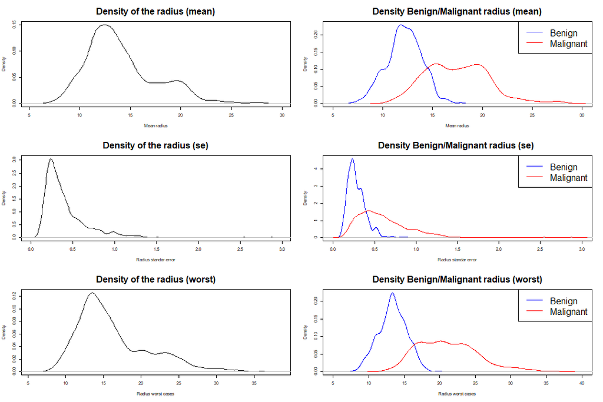

### Perimeter

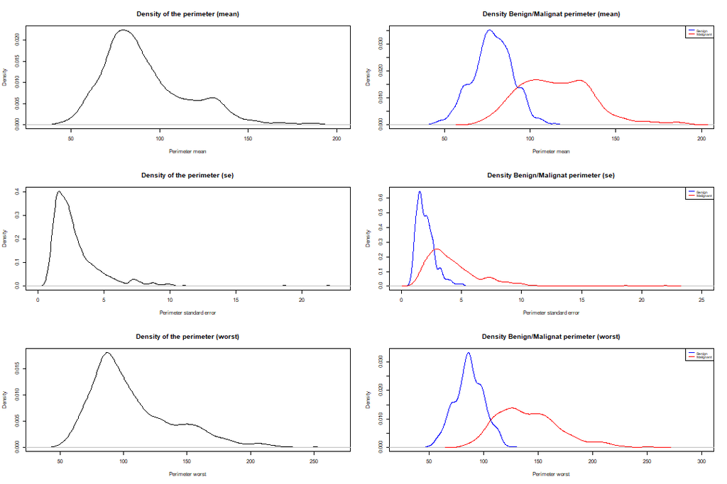

### Area

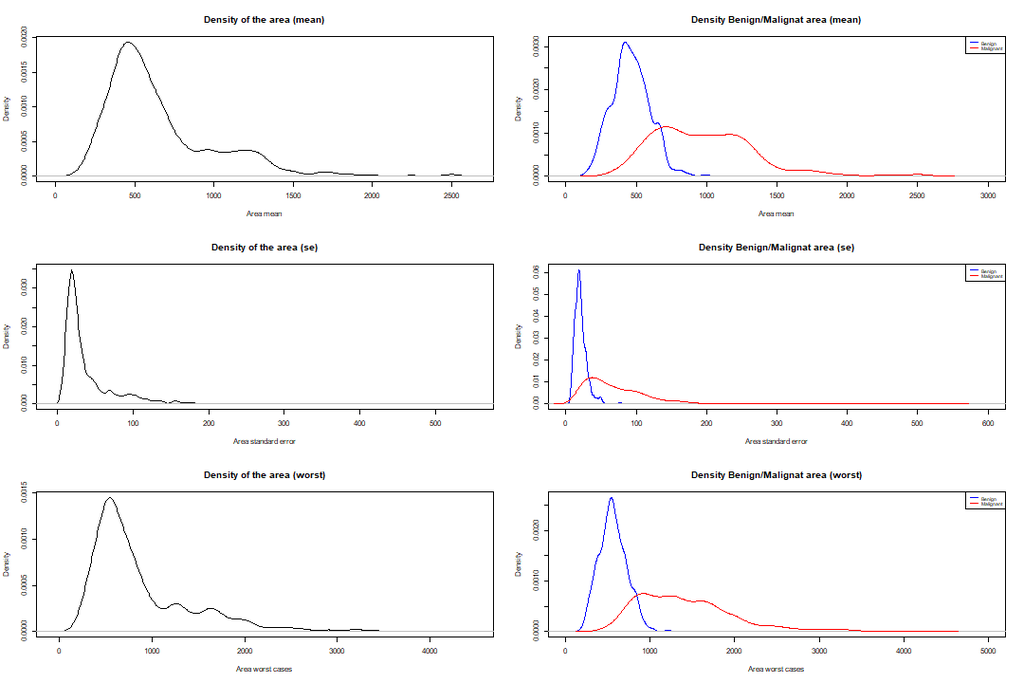

### Texture

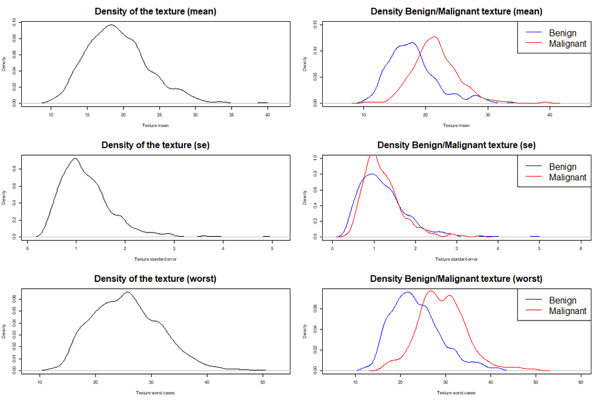

### Smoothness

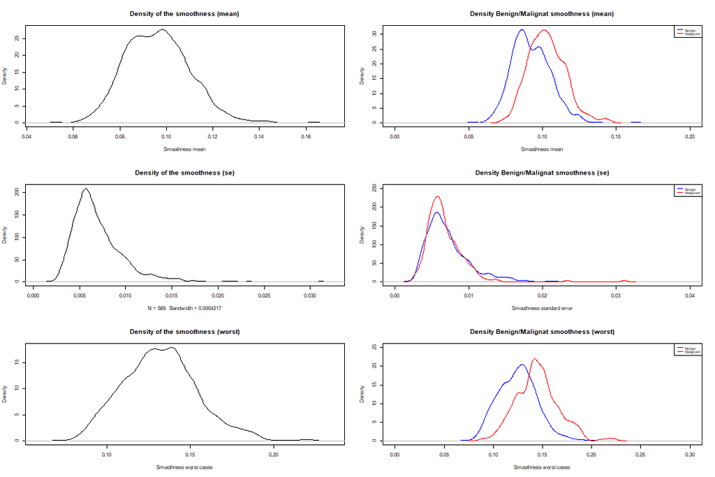

### Compactness

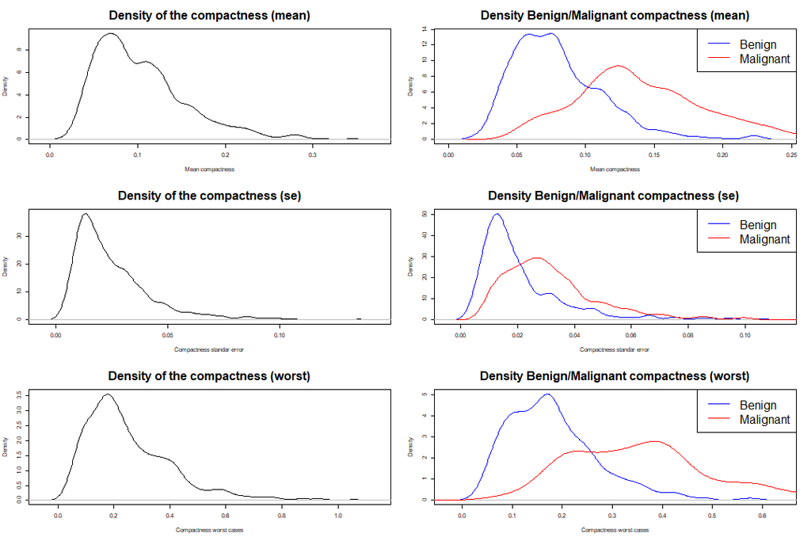

### Concavity

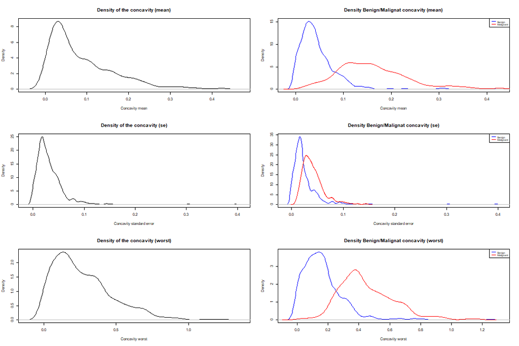

### Concave points

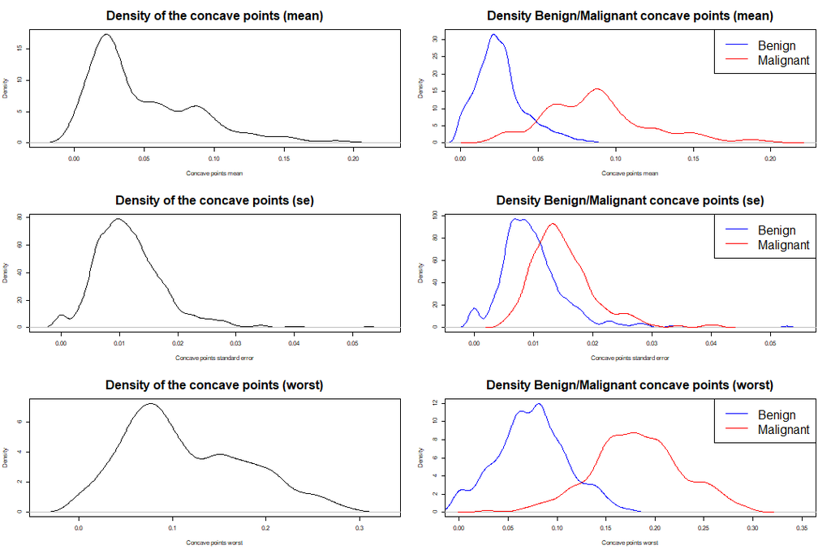

### Symmetry

[figure not shown]

### Fractal dimension

[figure not shown]

### Scatterplots

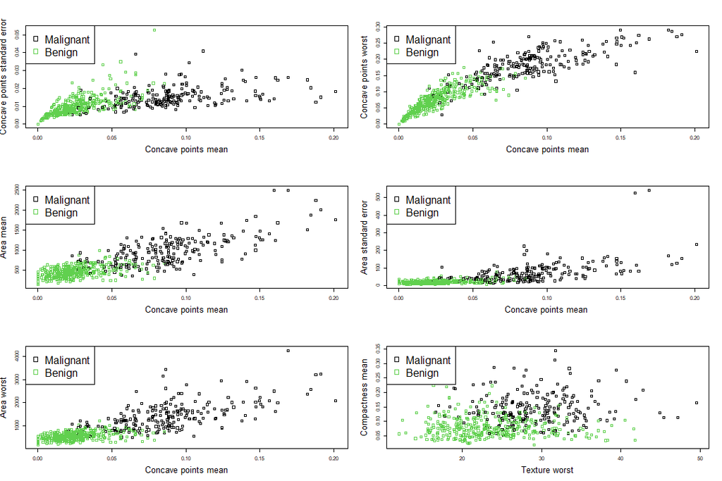

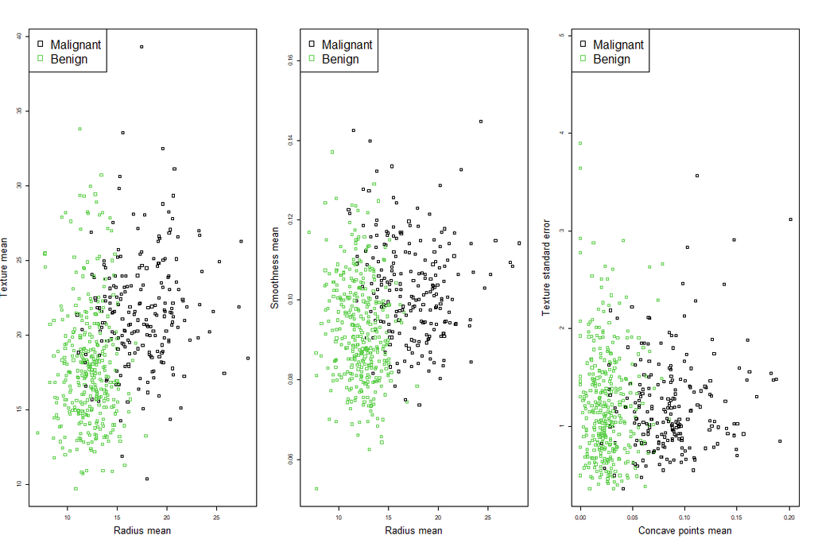

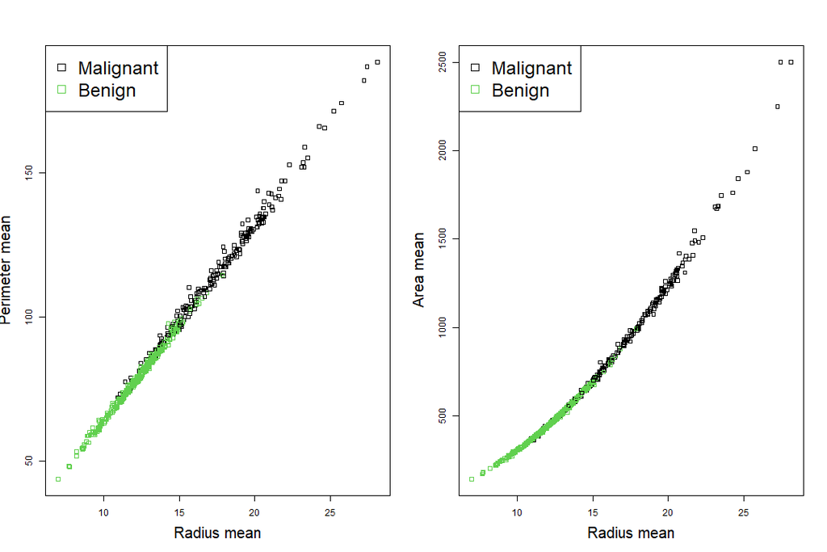

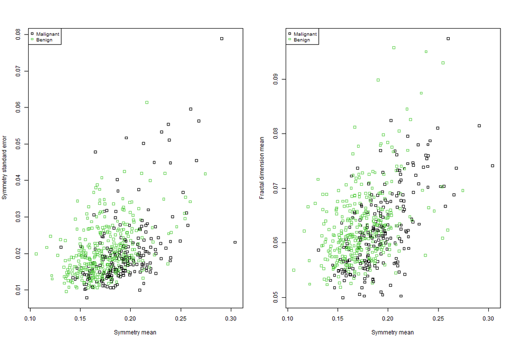

### Summary

- In general cancer cells have higher values more frequently than benign ones

We decided to try to predict the diagnosis of a tumor by using all the other features present in the dataset.  
This is a binary classification problem.

### Classification

We implemented 3 different models in order to succeed in our task:

- Logistic regression
- LDA
- QDA

We also randomly divided our dataset in 2 parts:

- 80% of the observation were used as a training set
- 20% as the validation set

### Logistic regression

The fitting algorithm did not converge and all predictor p-value was almost one so we did a constraint-based backward stepwise selection. We were left with 8 predictors and are the following:

- mean concavity
- radius standard error
- texture standard error
- compactness standard error
- number of concave points standard error
- worst cases radius
- worst cases texture
- worst cases symmetry

### Confusion Matrix and Metrics

```
        Y_val
glm_pred  0  1
       0 68  5
       1  1 40
```

```
       Metric      Value
1    Mis.err. 0.05263158
2   Precision 0.97560976
3 Sensitivity 0.88888889
4 Specificity 0.98550725
5 Neg.pred.V. 0.93150685
```

### LDA

By implementing linear discriminant analysis (LDA) we got the following metrics and confusion matrix as a measure of our performances:

```
         Y_val
lda.class  0  1
        0 68  5
        1  1 40
```

```
       Metric      Value
1    Mis.err. 0.05263158
2   Precision 0.97560976
3 Sensitivity 0.88888889
4 Specificity 0.98550725
5 Neg.pred.V. 0.93150685
```

### QDA

Similarly as before by implementing quadratic discriminant analysis (QDA) we got the following metrics and confusion matrix as a measure of our performances:

```
         Y_val
qda.class  0  1
        0 63  3
        1  6 42
```

```
       Metric      Value
1    Mis.err. 0.07894737
2   Precision 0.87500000
3 Sensitivity 0.93333333
4 Specificity 0.91304348
5 Neg.pred.V. 0.95454545
```

### Conclusion

```
       Metric        LDA        QDA   Log reg.
1    Mis.err. 0.05263158 0.07894737 0.05263158
2 Neg.pred.V. 0.93150685 0.95454545 0.93150685
3   Precision 0.97560976 0.87500000 0.97560976
4 Sensitivity 0.88888889 0.93333333 0.88888889
5 Specificity 0.98550725 0.91304348 0.98550725
```

- Log. reg. and LDA have less misclassification error
- QDA has better negative predicted value and sensitivity